# Topic 1 Exercises

### (iv)

```r
Elite <- rep("No", nrow(College))
Elite[College$Top10perc > 50] <- "Yes"
Elite <- as.factor(Elite)
College <- data.frame(College , Elite)

summary(College$Elite)
```

```
##  No Yes
## 699  78
```

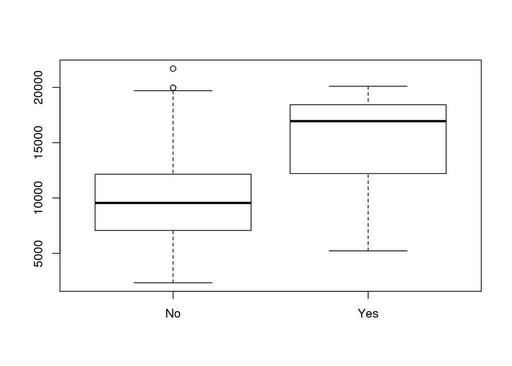

```r
plot(College$Elite, College$Outstate)
```

### (v)

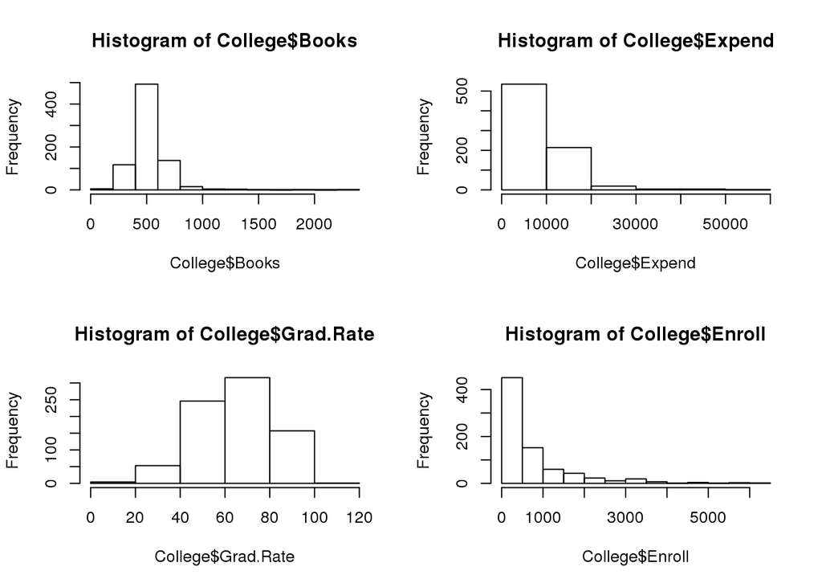

```r
par(mfrow=c(2, 2))
hist(College$Books, 10)
hist(College$Expend, 6)
hist(College$Grad.Rate, 5)
hist(College$Enroll, 10)
```

### (vi)

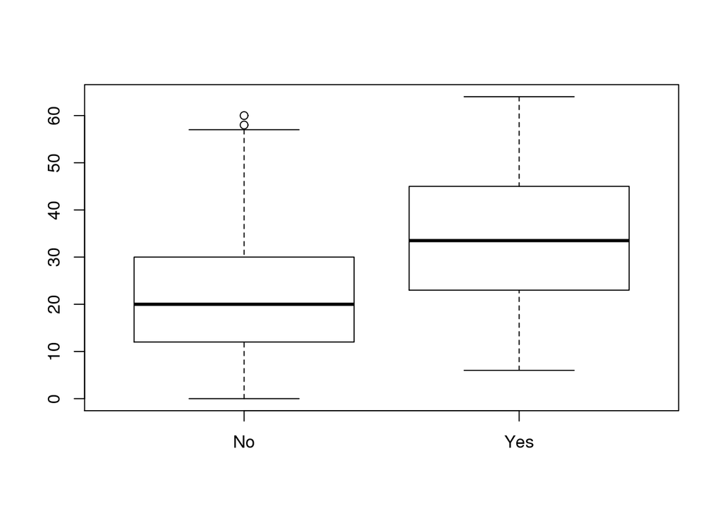

```r
plot(College$Elite, College$perc.alumni)
```

I thought it was interesting how the percentage of alumni who donate to their school is higher for elite colleges. This is likely because those alumni tend to have higher incomes, but I imagine school pride might also be a factor here.

# Exercise 9 in ISL § 2.4

## (a)

```r
sapply(Auto, class)
```

```
##          mpg    cylinders displacement   horsepower       weight
##    "numeric"    "numeric"    "numeric"    "numeric"    "numeric"
## acceleration         year       origin         name
##    "numeric"    "numeric"    "numeric"     "factor"
```

```r
range(Auto$mpg)
```

```
## [1]  9.0 46.6
```

```r
range(Auto$cylinders)
```

```
## [1] 3 8
```

```r
range(Auto$displacement)
```

```
## [1]  68 455
```

```r
range(Auto$horsepower)
```

```
## [1]  46 230
```

```r
range(Auto$weight)
```

```
## [1] 1613 5140
```

```r
range(Auto$acceleration)
```

```
## [1]  8.0 24.8
```

```r
range(Auto$year)
```

```
## [1] 70 82
```

```r
range(Auto$origin)
```

```
## [1] 1 3
```

## (c)

```r
mean(Auto$mpg)
```

```
## [1] 23.44592
```

```r
sd(Auto$mpg)
```

```
## [1] 7.805007
```

```r
mean(Auto$cylinders)
```

```
## [1] 5.471939
```

```r
sd(Auto$cylinders)
```

```
## [1] 1.705783
```

```r
mean(Auto$displacement)
```

```
## [1] 194.412
```

```r
sd(Auto$displacement)
```

```
## [1] 104.644
```

```r
mean(Auto$horsepower)
```

```
## [1] 104.4694
```

```r
sd(Auto$horsepower)
```

```
## [1] 38.49116
```

```r
mean(Auto$weight)
```

```
## [1] 2977.584
```

```r
sd(Auto$weight)
```

```
## [1] 849.4026
```

```r
mean(Auto$acceleration)
```

```
## [1] 15.54133
```

```r
sd(Auto$acceleration)
```

```
## [1] 2.758864
```

```r
mean(Auto$year)
```

```
## [1] 75.97959
```

```r
sd(Auto$year)
```

```
## [1] 3.683737
```

```r
mean(Auto$origin)
```

```
## [1] 1.576531
```

```r
sd(Auto$origin)
```

```
## [1] 0.8055182
```

## (d)

```r
subAuto <- Auto[-c(10,85)]

range(subAuto$mpg)
```

```
## [1]  9.0 46.6
```

```r
mean(subAuto$mpg)
```

```
## [1] 23.44592
```

```r
sd(subAuto$mpg)
```

```
## [1] 7.805007
```

```r
range(subAuto$cylinders)
```

```
## [1] 3 8
```

```r
mean(subAuto$cylinders)
```

```
## [1] 5.471939
```

```r
sd(subAuto$cylinders)
```

```
## [1] 1.705783
```

```r
range(subAuto$displacement)
```

```
## [1]  68 455
```

```r
mean(subAuto$displacement)
```

```
## [1] 194.412
```

```r
sd(subAuto$displacement)
```

```
## [1] 104.644
```

```r
range(subAuto$horsepower)
```

```
## [1]  46 230
```

```r
mean(subAuto$horsepower)
```

```
## [1] 104.4694
```

```r
sd(subAuto$horsepower)
```

```
## [1] 38.49116
```

```r
range(subAuto$weight)
```

```
## [1] 1613 5140
```

```r
mean(subAuto$weight)
```

```
## [1] 2977.584
```

```r
sd(subAuto$weight)
```

```
## [1] 849.4026
```

```r
range(subAuto$acceleration)
```

```
## [1]  8.0 24.8
```

```r
mean(subAuto$acceleration)
```

```
## [1] 15.54133
```

```r
sd(subAuto$acceleration)
```

```
## [1] 2.758864
```

```r
range(subAuto$year)
```

```
## [1] 70 82
```

```r
mean(subAuto$year)
```

```
## [1] 75.97959
```

```r
sd(subAuto$year)
```

```
## [1] 3.683737
```

```r
range(subAuto$origin)
```

```
## [1] 1 3
```

```r
mean(subAuto$origin)
```

```
## [1] 1.576531
```

```r
sd(subAuto$origin)
```

```
## [1] 0.8055182
```

## (e)

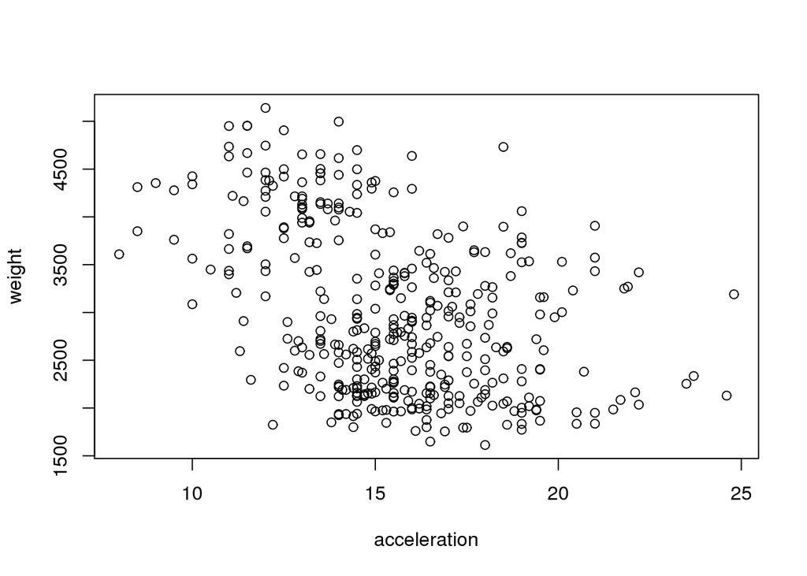

```r
plot(Auto$acceleration, Auto$weight, xlab="acceleration", ylab="weight")
```

The higher the weight of a car, the lower its acceleration. The relationship here is not too strong, and the values are spread out. But we can see that the points in the right (higher acceleration) have a lower y value (weight).

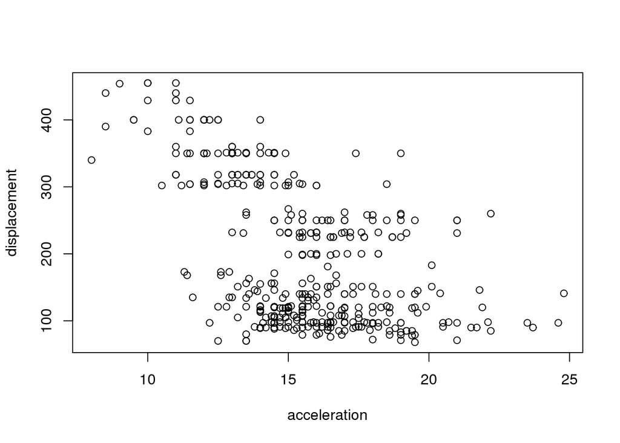

```r
plot(Auto$acceleration, Auto$displacement, xlab="acceleration", ylab="displacement")
```

The higher the displacement, the lower the car’s acceleration. We can see that the points in the right (higher acceleration) have a lower y value (displacement).

## (f)

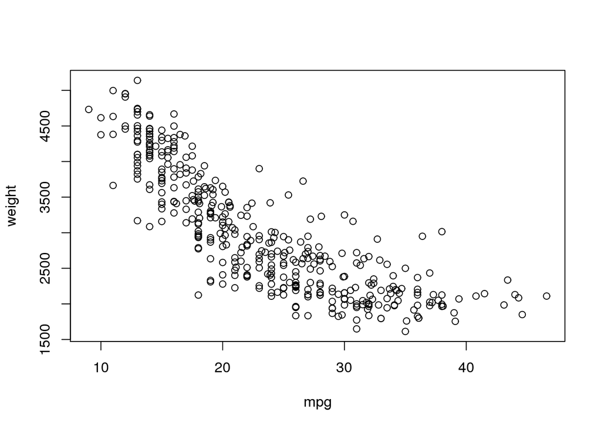

```r
plot(Auto$mpg, Auto$weight, xlab="mpg", ylab="weight")
```

It seems that the higher the weight of a car, the lower its mpg. We can see that the points in the right (higher mpg) have a lower y value (weight).

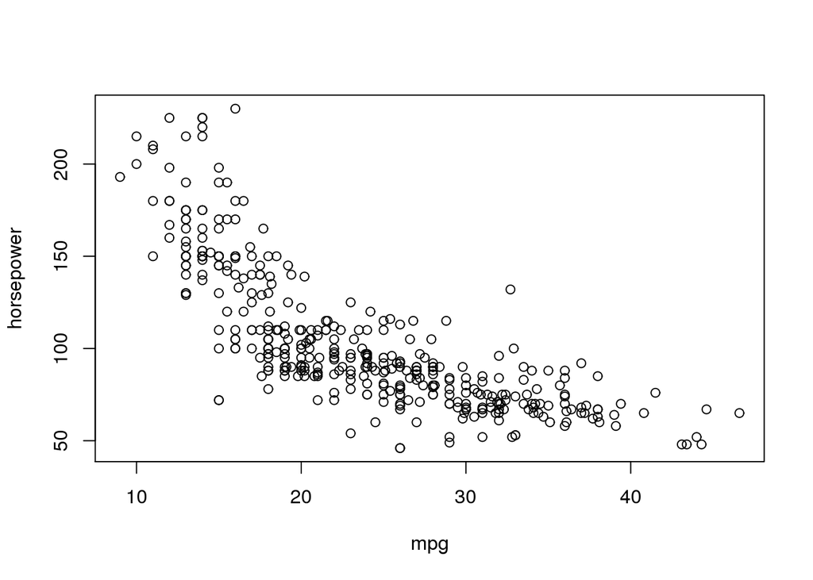

```r
plot(Auto$mpg, Auto$horsepower, xlab="mpg", ylab="horsepower")
```

It seems that the higher the horsepower of a car, the lower its mpg. We can see that the points in the right (higher mpg) have a lower y value (horsepower).

# Exercise 2 in ISL § 2.4

## (a)

It is a regression problem since we are only looking at quantitative variables. We are most interested in infering the relationship between CEO salary and the other variables. n = 500 p = 4 (profit, number of employees, industry and CEO salary)

## (b)

It is a classification problem since we are trying to classify whether the nre product will be a success or a failure. We are most interested in predicting the success or failure of the product. n = 20 p = 14 (whether it was a success or failure, price charged for the product, marketing budget, competition price, and 10 other variables)

## (c)

It is a regression problem since the outcome is a quantitative value. We are most interested in predicting the % change in US dollar for future weeks. n = 52 (number of weeks in a year) p = 4 (% change in the dollar, the % change in the US market, the % change in the British market, and the % change in the German market)

# Exercise 7 in ISL § 2.4

## (a)

```r
sqrt((0-0)^2 + (3-0)^2 + (0-0)^2)
```

```
## [1] 3
```

```r
sqrt((2-0)^2 + (0-0)^2 + (0-0)^2)
```

```
## [1] 2
```

```r
sqrt((0-0)^2 + (1-0)^2 + (3-0)^2)
```

```
## [1] 3.162278
```

```r
sqrt((0-0)^2 + (1-0)^2 + (2-0)^2)
```

```
## [1] 2.236068
```

```r
sqrt((-1-0)^2 + (0-0)^2 + (1-0)^2)
```

```
## [1] 1.414214
```

```r
sqrt((1-0)^2 + (1-0)^2 + (1-0)^2)
```

```
## [1] 1.732051
```

## (b)

Green. When K=1, we only consider the closest observation, #5, which has a Y of “Green”.

## (c)

Red. Adding the next 2 closest observations (#6 and #2, both of which have a Y of “Red”) we have a 1/3 chance that it is green and a 2/3 chance that it is red. We go with the higher probability.

## (d)

As K grows, the model becomes less flexible, which would be better suited for linear distributions. Therefore, we expect the best value for K to be small.